# HW_4.Popova

Popova Svetlana

2024-03-31

# 1. Артериальная гипертензия

```r
# Задаем seed для воспроизводимости
set.seed(42)

# Размер выборки
sample_size <- 30

# Среднее артериальное давление
mu_before <- 140 # до приема нового препарата
mu_after <- 125 # после приема нового препарата

# Данные
data_before <- rnorm(sample_size, mu_before, 10)
data_after <- rnorm(sample_size, mu_after, 10)
```

Гипотезы:

Нулевая гипотеза (H0): В среднем, новый препарат не приводит к изменению артериального давления по сравнению со стандартной терапией. Альтернативная гипотеза (H1): В среднем, новый препарат приводит к снижению артериального давления по сравнению со стандартной терапией.

```r
# Уровень значимости
alpha <- 0.05
```

так как размер выборки 30 и сравниваем 2 группы, будем проводить t-тест

```r
# Проводим t-тест
t.test(x = data_before, y = data_after, paired = TRUE, alternative = "less")
```

```
##
##  Paired t-test
##
## data:  data_before and data_after
## t = 5.1636, df = 29, p-value = 1
## alternative hypothesis: true mean difference is less than 0
## 95 percent confidence interval:
##      -Inf 22.46764
## sample estimates:
## mean difference
##        16.90495
```

p-значение (1) больше уровня значимости (обычно 0.05): Мы не можем отвергнуть нулевую гипотезу, которая гласит, что нет статистически значимой разницы между средними значениями “до” и “после”. Недостаточно оснований, чтобы утверждать о статистически значимом снижении артериального давления

# 2. Связь между курением и раком легких

```r
# Задаем seed для воспроизводимости
set.seed(42)

# Размер выборки
sample_size1 <- 100
sample_size2 <- 30

# Вероятности развития рака
prob_smoker <- 0.8
prob_nonsmoker <- 0.2

# Генерируем данные по курению
smoking_status1 <- c(rep("smoker", sample_size1 / 2), rep("nonsmoker", sample_size1 / 2))
smoking_status2 <- c(rep("smoker", sample_size2 / 2), rep("nonsmoker", sample_size2 / 2))

# Генерируем данные по раку
sample_size1 <- 100
sample_size2 <- 30



generate_cancer_status <- function(smoking_status, prob_smoker, prob_nonsmoker) {
  if (smoking_status == "smoker") {
    return(rbinom(1, 1, prob_smoker))  # 1 - заболел, 0 - не заболел
  } else {
    return(rbinom(1, 1, prob_nonsmoker))
  }
}

# Первая выборка по раку 1
cancer_status1 <- sapply(smoking_status1, generate_cancer_status, prob_smoker, prob_nonsmoker)

# Вторая выборка по раку
cancer_status2 <- sapply(smoking_status2, generate_cancer_status, prob_smoker, prob_nonsmoker)
```

Гипотезы:

Нулевая гипотеза (H0): Нет связи между курением и раком легких.

Альтернативная гипотеза (H1): Существует связь между курением и раком легких, и курящие люди имеют более высокую вероятность заболеть раком легких, чем некурящие.

```r
# Уровень значимости
alpha <- 0.05
```

Выбор теста:

Хи-квадрат тест: Подходит для проверки связи между двумя категориальными переменными. В данном случае: курение (курящий/некурящий) и наличие рака легких (да/нет). Как видно далее в таблице сопряженности, значения не менее 5, а сумма больше 50, поэтому можно не использовать критерий Фишера

```r
# Таблица сопряженности
table1 <- table(smoking_status1, cancer_status1)

# Проводим хи-квадрат тест
chisq.test(table1)
```

```
##
##  Pearson's Chi-squared test with Yates' continuity correction
##
## data:  table1
## X-squared = 29, df = 1, p-value = 7.236e-08
```

```r
# Таблица сопряженности
table2 <- table(smoking_status2, cancer_status2)

# Проводим хи-квадрат тест
chisq.test(table2)
```

```
##
##  Pearson's Chi-squared test with Yates' continuity correction
##
## data:  table2
## X-squared = 8.5333, df = 1, p-value = 0.003487
```

```r
table1
```

```
##                cancer_status1
## smoking_status1  0  1
##       nonsmoker 45  5
##       smoker    18 32
```

Выборка 1 (n = 100):

X-квадрат = 29, df = 1, p-value = 7.236e-08. p-value (меньше уровня значимости, обычно 0.05) указывает на статистически значимую связь между курением и раком легких. Это означает, что в выборке 1 курящие имеют значительно более высокий риск заболевания раком легких, чем некурящие.

Выборка 2 (n = 30):

X-квадрат = 8.5333, df = 1, p-value = 0.003487. p-value (меньше уровня значимости) также указывает на статистически значимую связь. Однако, из-за меньшего размера выборки (n = 30) результат менее надежный, чем в выборке 1.

Общий вывод:

Данные обеих выборок (n = 100 и n = 30) подтверждают наличие статистически значимой связи между курением и развитием рака легких. Курящие люди имеют значительно более высокий риск заболевания по сравнению с некурящими.

# 3. Проверка гипотезы о новом методе лечения синдрома раздраженного кишечника

### 1. Нулевая и альтернативная гипотезы:

3. **H0 (нулевая гипотеза):** Новый метод лечения **не** приводит к значимому изменению уровня болевых симптомов по сравнению с диетотерапией.

   **H1 (альтернативная гипотеза):** Новый метод лечения **приводит** к значимому изменению уровня болевых симптомов по сравнению с диетотерапией.

### 2. Уровень значимости:

   Обычно уровень значимости (alpha) устанавливается на уровне **0,05**. Это означает, что мы готовы принять 5% вероятность ошибочного отклонения нулевой гипотезы (ошибка I рода).

### 3. Выбор статистического теста:

   Поскольку исследователь избегает каких-либо предположений о распределении данных, **непараметрический тест** будет наиболее подходящим.

   В данном случае, **тест Манна-Уитни U** является хорошим выбором, так как он сравнивает **ранги** данных в двух независимых группах.

### 4. Наблюдаемое и критическое значение статистики:

   Для определения наблюдаемого значения U-статистики и критического значения, необходимо иметь фактические данные (уровни боли) для обеих групп.

```r
# размер выборки
n <- 20

# параметры распределения
mean_1 <- 5 # среднее для группы 1
mean_2 <- 7 # среднее для группы 2
sd <- 2 # стандартное отклонение для обеих групп

# генерируем данные уровня боли
set.seed(123) # для воспроизводимости
группа_1 <- round(rnorm(n, mean_1, sd))
группа_2 <- round(rnorm(n, mean_2, sd))

# объединяем данные в датафрейм
df <- data.frame(
  группа = c(rep("диета", n), rep("новый метод", n)),
  уровень_боли = c(группа_1, группа_2)
)
```

```r
# Выполните тест Манна-Уитни U
result <- wilcox.test(уровень_боли ~ группа, data = df)

# Наблюдаемое значение U-статистики
observed_U <- result$statistic

# p-значение
p_value <- result$p.value

# Уровень значимости
alpha <- 0.05

# Критическое значение U (односторонний тест)
critical_U <- qwilcox(1 - alpha, n, n)

# Вывод:
cat("Наблюдаемое U:", observed_U, "\n")
```

```
## Наблюдаемое U: 99.5
```

```r
cat("Критическое U:", critical_U, "\n")
```

```
## Критическое U: 261
```

```r
cat("p-значение:", p_value, "\n")
```

```
## p-значение: 0.006056817
```

```r
if (p_value < alpha) {
  cat("Отклоняем H0: есть значимое различие.\n")
} else {
  cat("Не отклоняем H0: нет достаточных доказательств.\n")
}
```

```
## Отклоняем H0: есть значимое различие.
```

- Критическое значение - табличное значение, которое можно взять из фунции qwilcox, передав в нее наши значения
- Отклоняем нулевую гипотезу., т.е. p-value 0.006056817, что меньше 0,05
- **Существует статистически значимое различие** **между средними уровнями боли в группах диеты и нового метода лечения**

# 4. Противоопухолевые препараты

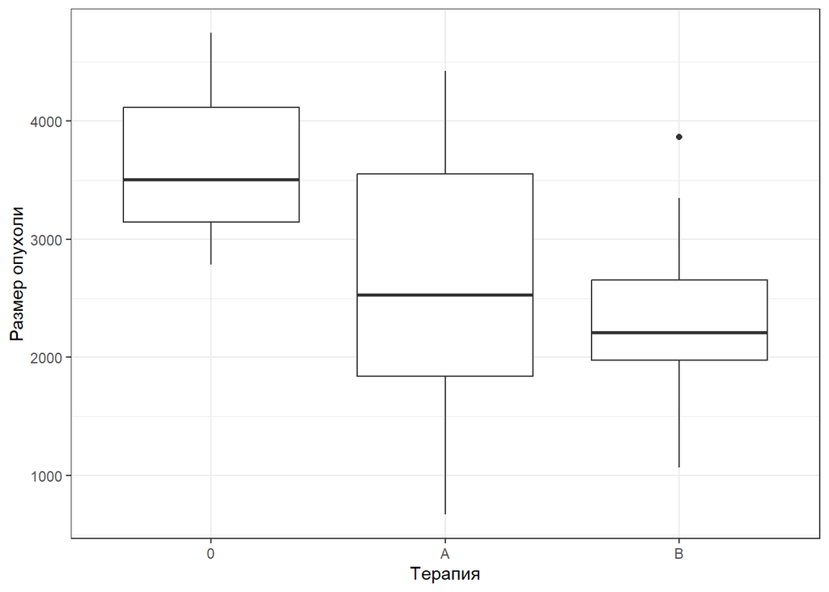

```r
# 1. Генерация датасета
set.seed(42)

tumor <- tibble(
  therapy = c(rep("0", 10), rep("A", 10), rep("B", 10)),
  value = c(rep(3213, 10), rep(2687, 10), rep(2423, 10))
) %>%
  mutate(therapy = factor(therapy, levels = c("0", "A", "B")))

tumor$value <- tumor$value + rnorm(30, 0, 760)

# 2. Построение "ящиков с усами"
library(ggplot2)

ggplot(tumor, aes(x = therapy, y = value)) +
  geom_boxplot() +
  labs(x = "Терапия", y = "Размер опухоли") +
  theme_bw()
```

```r
# 3. Дисперсионный анализ (ANOVA)
model <- aov(value ~ therapy, data = tumor)
summary(model)
```

```
##             Df   Sum Sq Mean Sq F value  Pr(>F)
## therapy      2 10038199 5019099   5.555 0.00954 **
## Residuals   27 24397392  903607
## ---
## Signif. codes:  0 '***' 0.001 '**' 0.01 '*' 0.05 '.' 0.1 ' ' 1
```

- F-статистика (F value): 5.555
- p-значение (Pr(>F)): 0.00954

Интерпретация:

- p-значение (0.00954) < 0.05:
  - Отклоняем нулевую гипотезу.
  - Существует статистически значимое различие между средними размерами опухолей хотя бы в одной группе.
- Результаты ANOVA свидетельствуют о том, что тип терапии оказывает влияние на размер опухоли у мышей.

Однако ANOVA не говорит нам, какие именно группы отличаются друг от друга.

Для этого необходимо выполнить попарные сравнения, например, с помощью попарного теста Тьюки.

```r
# 4. Попарные сравнения Тьюки (TukeyHSD)
TukeyHSD(model)
```

```
##   Tukey multiple comparisons of means
##     95% family-wise confidence level
##
## Fit: aov(formula = value ~ therapy, data = tumor)
##
## $therapy
##           diff       lwr        upr     p adj
## A-0 -1066.1727 -2120.206  -12.13892 0.0470127
## B-0 -1341.2860 -2395.320 -287.25225 0.0105799
## B-A  -275.1133 -1329.147  778.92041 0.7955378
```

**Вывод:**

- **Оба препарата A и B приводят к статистически значимому снижению размера опухоли по сравнению с плацебо.**
- **Нет статистически значимой разницы в эффективности между препаратами A и B.**